# Linear regression: the basics

Jeffrey Chrabaszcz  
7 January 2014

### Data science

[figure not shown]

### Outline

1. Linear model
2. Multiple predictors
3. Interactions
4. Statistical inference
5. Graphical displays of data and fitted model
6. Assumptions and diagnostics
7. Prediction and validation

### Linear model

Recall that the linear model is:

\[ y_i = \beta_0 + \beta_1x_{1i} + \beta_2x_{2i} + ... + \epsilon_i\\ \hat{y} = \beta_0 + \beta_1x_{1i} + ... + \beta_kx_{ki} \]

This means that, for some sample, our best prediction of each value of \( y \) is:

- \( \beta_0 \), the intercept term; plus,
- the weighted value of each predictor, \( x \), multiplied by some weight, \( \beta \).
- \( \epsilon \) also gives us an idea of how for off we expect to be with each prediction.

### Quick aside

The data for this next bit were originally formatted for Stata, (another statistical analysis software). This is what it took to get those data into R.

```r
library(foreign)
df <- read.dta("data/kidiq.dta")
head(df)
```

```
  kid_score mom_hs mom_iq mom_work mom_age
1        65      1  121.1        4      27
2        98      1   89.4        4      25
3        85      1  115.4        4      27
4        83      1   99.4        3      25
5       115      1   92.7        4      27
6        98      0  107.9        1      18
```

### Simple linear regression

Let's say we want to predict a child's IQ based on whether or not the mother completed highschool. We can look at this relationship graphically.

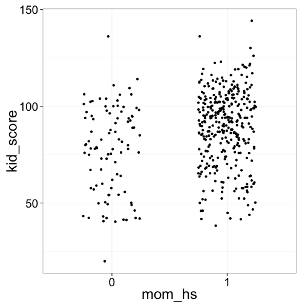

```r
df$mom_hs <- factor(df$mom_hs)
qplot(mom_hs, kid_score, data = df, geom = "jitter", position = position_jitter(width = .25))
```

### Alternately, boxplots for a single categorical predictor

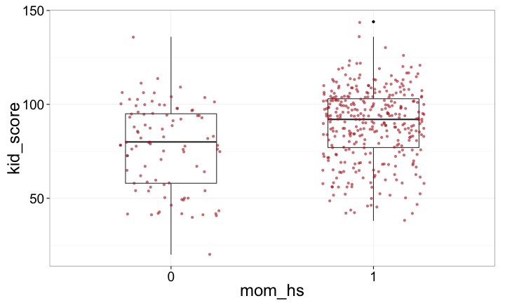

```r
ggplot(df, aes(mom_hs, kid_score)) + geom_boxplot(width = .6) + geom_jitter(color = "firebrick", alpha = .6, position = position_jitter(width = .25)) + theme_bw(base_size = 24)
```

### t test

```r
t.test(kid_score ~ mom_hs, data = df, var.equal = TRUE)
```

```
    Two Sample t-test

data:  kid_score by mom_hs
t = -5.07, df = 432, p-value = 5.957e-07
alternative hypothesis: true difference in means is not equal to 0
95 percent confidence interval:
 -16.34  -7.21
sample estimates:
mean in group 0 mean in group 1
           77.5            89.3
```

### Code you will use a million times

This is the code we'll use to predict kid's IQ based on mom's HS completion. We assigned our data to the data.frame named **df**, so that's also specified.

```r
my.lm <- lm(kid_score ~ mom_hs, data = df)
```

This is just here for reference, you'll use this code many times in the next 2 weeks.

### Display a linear model

\[ \widehat{kid\,score} = 78 + 12 \cdot mom\,hs \]

```r
display(my.lm)
```

```
lm(formula = kid_score ~ mom_hs, data = df)
            coef.est coef.se
(Intercept) 77.55     2.06
mom_hs1     11.77     2.32
---
n = 434, k = 2
residual sd = 19.85, R-Squared = 0.06
```

### Summary of a linear model

```
Call:
lm(formula = kid_score ~ mom_hs, data = df)

Residuals:
   Min     1Q Median     3Q    Max
-57.55 -13.32   2.68  14.68  58.45

Coefficients:
            Estimate Std. Error t value Pr(>|t|)
(Intercept)    77.55       2.06   37.67   <2e-16
mom_hs1        11.77       2.32    5.07    6e-07

Residual standard error: 19.9 on 432 degrees of freedom
Multiple R-squared:  0.0561,    Adjusted R-squared:  0.0539
F-statistic: 25.7 on 1 and 432 DF,  p-value: 5.96e-07
```

### Continuous predictor

\[ \widehat{kid\,score} = 26 + 0.6 \cdot mom\,IQ \]

```
lm(formula = kid_score ~ mom_iq, data = df)
            coef.est coef.se
(Intercept) 25.80     5.92
mom_iq       0.61     0.06
---
n = 434, k = 2
residual sd = 18.27, R-Squared = 0.20
```

### Connecting marginal means

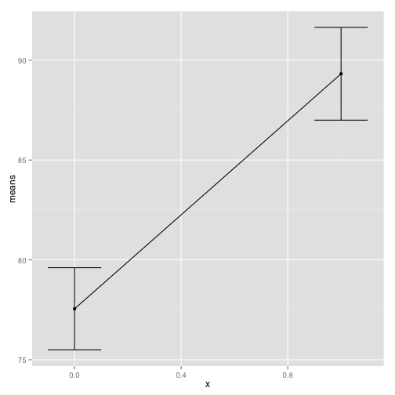

```r
ggplot(a, aes(x, means)) + geom_point() + geom_line(group = 1) + geom_errorbar(aes(ymin = means - ses, ymax = means + ses), width = .2)
```

### Connecting marginal means

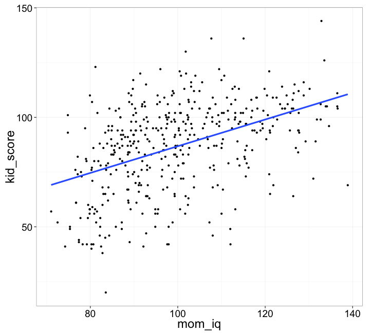

### Naming conventions

I will not be using any of the following names in this class, but early statisticians did not have the benefit of hindsight.

[output not shown]

### Multiple predictors

\[ \widehat{kid\,score} = 26 + 6 \cdot mom\,hs + 0.6 \cdot mom\,IQ \]

```r
display(my.lm2)
```

```
lm(formula = kid_score ~ mom_hs + mom_iq, data = df)
            coef.est coef.se
(Intercept) 25.73     5.88
mom_hs1      5.95     2.21
mom_iq       0.56     0.06
---
n = 434, k = 3
residual sd = 18.14, R-Squared = 0.21
```

### Visualizing multiple predictors

Heavily dependent on the nature of your predictors!

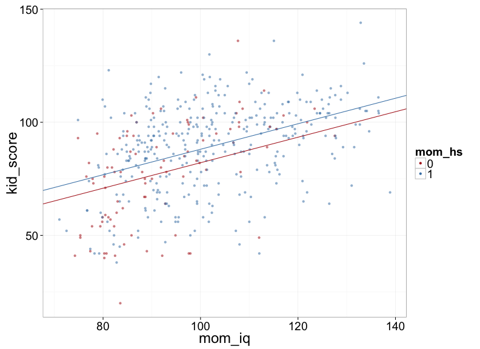

### Interactions

```
lm(formula = kid_score ~ mom_hs * mom_iq, data = df)
               coef.est coef.se
(Intercept)    -11.48    13.76
mom_hs1         51.27    15.34
mom_iq           0.97     0.15
mom_hs1:mom_iq  -0.48     0.16
---
n = 434, k = 4
residual sd = 17.97, R-Squared = 0.23
```

### Plotting interactions

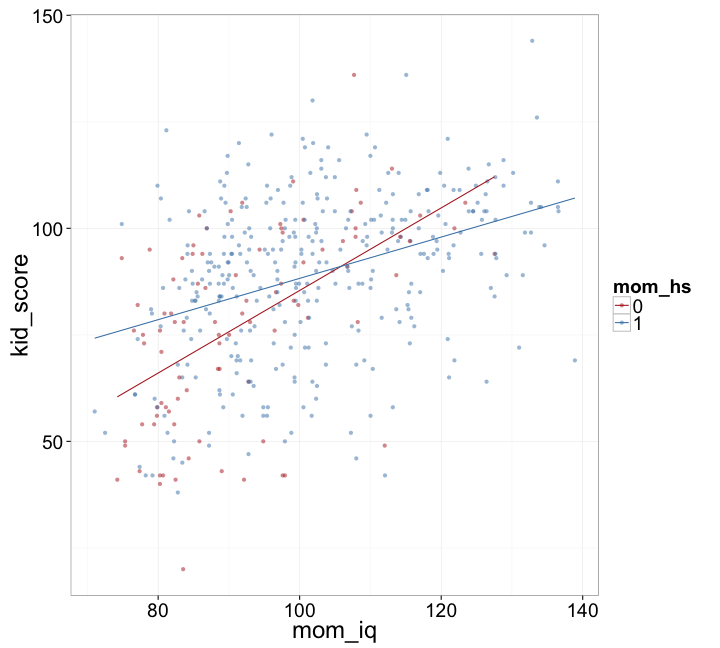

### Plotting interactions, cont.

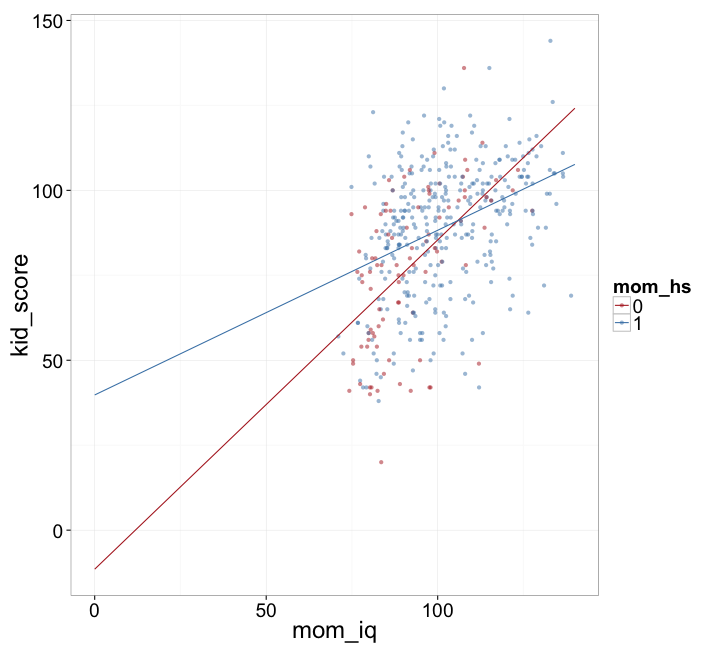

### Interpretting interactions

Other things:

- interaction interpretability is improved by pre-processing (tomorrow)
- interactions help data models fit different subsets of data well (last few classes)

### Statistical inference

## Units

People or schools, not pounds or inches, (the “other” units matter, though!)

## Outcome and predictors

The thing we're predicting. We don't talk about independent and dependent variables, those words are already used for other things. Same goes for predictors instead of independent variables.

That last regression has:

- four predictors
  - intercept
  - mom HS
  - mom IQ
  - mom HS \( \cdot \) mom IQ
- two inputs
  - mom's IQ
  - mom's high school status

### Residuals

Residuals represent the uncertainty left after removing predicted variance.

\[ r_i = y_i - \hat{y}_i \]

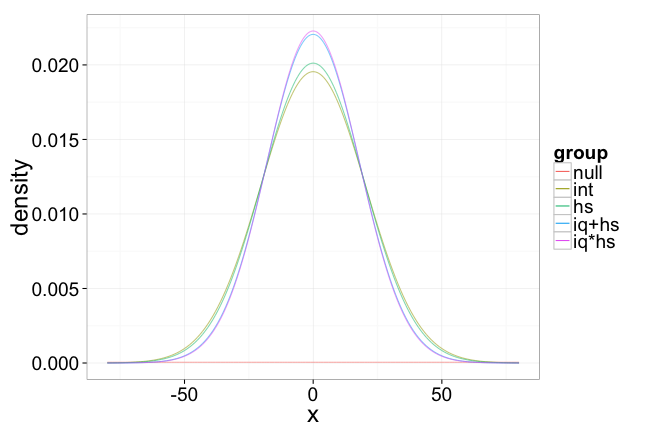

## residual variance

- remaining variance is uncertainty in your outcome
- original variance - error variance is your explained error as a proportion
- use this to know how far off our estimates should be
- Adjusted \( R^2 \) is generally the same as explained error with a penalty for the number of parameters

### Prediction and validation

**“prediction” standard errors**

```r
predict(my.lm1, x.new, interval="confidence", level=0.95)
```

```
   fit  lwr  upr
1 86.8 85.1 88.5
```

```r
predict(my.lm1, x.new, interval="prediction", level=0.95)
```

```
   fit  lwr upr
1 86.8 50.9 123
```

**split-half cross-validation**

- Fit model to a random half of the dataset, check fit to remaining half.
- related to bootstrapping and simulation.

**external validation**

Fitting the same model to a new set of data.

**bootstrap/simulation**

We'll be covering this Friday.

### Assumptions and diagnostics

In order of importance:

1. Validity
2. Additivity & Linearity
3. Independence of errors
4. Equal variance of errors
5. Normality of errors